# Machine Learning et ADC

Borice DOSSOU

2024-09-04

```r
# Définition de la fonction
Generate_output <- function(N, a, b, c, U0) {
  # Initialisation U0
  U <- numeric(N + 1)
  U[1] <- U0

  # Boucle pour calculer les valeurs de U_n
  for (n in 1:N) {
    U[n + 1] <- a * U[n]^c + b
  }

  return(U)
}
```

La fonction de test de function

*Essai 1*

```r
test_Generate_output <- function(){
 a <- 2
 b <- 2
 c <- 1
 U0 <- 1
 N <- 2
 waited<-c(2,2,2,1,1,4,10)
 fun_out<-c(N,a,b,c,Generate_output(N,a,b,c,U0))
 if(all(waited==fun_out)){
   return("OK")
 }else{
   return("Error...")
   }
}
test_Generate_output()
```

```
## [1] "OK"
```

**Essai 2**

```r
test_Generate_output <- function(){
 a <- 2
 b <- 2
 c <- 1
 U0 <- 1
 N <- 1
 waited<-c(1,2,2,1,1,4)
 fun_out<-c(N,a,b,c,Generate_output(N,a,b,c,U0))
 if(all(waited==fun_out)){
   return("OK")
 }else{
   return("Error...")
   }
}
test_Generate_output()
```

```
## [1] "OK"
```

Après avoir Exécuter le code de la fonction. Je constate que le code marche alors je peux le deployer.

Generer les courbes selons les valeurs des paramètres Let N = 40, a ∈ [2; 5], b ∈ [1; 5] and , c ∈ [0.1; 0.9]

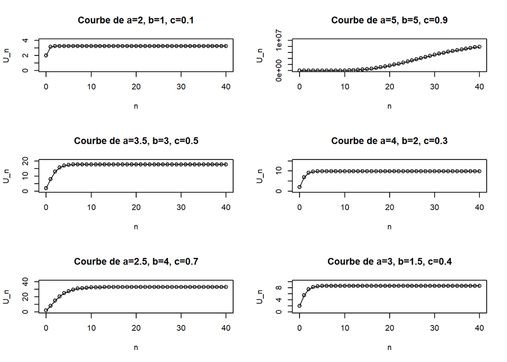

```r
# Pour rendre les résultats reproductibles (facultatif)
# Nombre d'itérations
N <- 40
U0 <- 2  # Valeur initiale de U(0)

# Paramètres pour la courbe 1
a1<-2
b1<-1
c1<-0.1
# Paramètres pour la courbe 2
a2<-5
b2<-5
c2<-0.9
# Paramètres pour la courbe 3
a3<-3.5
b3<-3
c3<-0.5
# Paramètres pour la courbe 4
a4 <- 4
b4 <- 2
c4 <- 0.3
# Paramètres pour la courbe 5
a5 <- 2.5
b5 <- 4
c5 <- 0.7
# Paramètres pour la courbe 6
a6 <- 3
b6 <- 1.5
c6 <- 0.4

# Pour permettre un affichage en grille des graphique
par(mfrow = c(3, 2))
# Générer et tracer la courbe 1
plot(0:N, Generate_output(N, a1,b1,c1, U0),
     type = "o", col = 1, ylim = c(0, 4),
     xlab = "n", ylab = "U_n",
     main = "Courbe de a=2, b=1, c=0.1")
# Générer et tracer la courbe 2
plot(0:N, Generate_output(N, a2,b2,c2, U0),
     type = "o", col = 1, ylim = c(0, 10^7),
     xlab = "n", ylab = "U_n",
     main = "Courbe de a=5, b=5, c=0.9")
# Générer et tracer la courbe 3
plot(0:N, Generate_output(N, a3,b3,c3, U0),
     type = "o", col = 1, ylim = c(0, 20),
     xlab = "n", ylab = "U_n",
     main = "Courbe de a=3.5, b=3, c=0.5")
# Générer et tracer la courbe 4
plot(0:N, Generate_output(N, a4, b4, c4, U0),
     type = "o", col = 1, ylim = c(0, 15),
     xlab = "n", ylab = "U_n",
     main = "Courbe de a=4, b=2, c=0.3")

# Générer et tracer la courbe 5
plot(0:N, Generate_output(N, a5, b5, c5, U0),
     type = "o", col = 1, ylim = c(0, 40),
     xlab = "n", ylab = "U_n",
     main = "Courbe de a=2.5, b=4, c=0.7")

# Générer et tracer la courbe 6
plot(0:N, Generate_output(N, a6, b6, c6, U0),
     type = "o", col = 1, ylim = c(0, 10),
     xlab = "n", ylab = "U_n",
     main = "Courbe de a=3, b=1.5, c=0.4")
```

Description des paramètres

a: contrôle le taux de croissance, b: agit comme un décalage vertical, c: modifie la non-linéarité de la croissance

**Exercise 2.2 Behavior of the parameters of the model**

1 ) La sensibilité des paramètres fait référence à la manière dont de petites variations des paramètres d’un modèle ou d’une équation affectent le comportement ou les résultats de ce modèle. En d’autres termes, si un paramètre change légèrement, la sensibilité mesure l’ampleur de la variation dans la sortie du modèle. Un système est dit sensible à un paramètre si une petite modification de ce dernier entraîne un changement significatif dans les résultats, tandis qu’il est insensible ou robuste si ces variations ont peu d’effet. La sensibilité est importante pour comprendre la stabilité d’un modèle et identifier les paramètres critiques qui influencent fortement le système.”“”

Approche : Fixer b et c à des valeurs constantes, puis augmenter ou diminuer progressivement a (par exemple, tester des valeurs dans l’intervalle [2,5]. Observer comment la vitesse de croissance de la suite change. Sensibilité : Si de petites variations de a entraînent de grandes différences dans la croissance ou la divergence de la suite, cela indique une grande sensibilité au paramètrea.

Dérivées partielles dU_da[n] <- U[n]^c ” la dérivée par rapport à a” dU_db[n] <- 1 ” la dérivée par rapport à b” dU_dc[n] <- a * U[n]^c * log(U[n]) ” la dérivée par rapport à c”

```r
# Fonction pour calculer les dérivées partielles
partial_derivatives <- function(N, a, b, c, U0) {
  U <- numeric(N+1)
  U[1] <- U0

  # Vecteurs pour stocker les dérivées
  dU_da <- numeric(N+1)
  dU_db <- numeric(N+1)
  dU_dc <- numeric(N+1)
  dU_da[1] <- U0^c
  dU_db[1] <- 1
  dU_dc[1] <- a * U0^c * log(U0)

  for (n in 1:N) {
    # Calcul de U_n+1
    U[n+1] <- a * U[n]^c + b

    # Dérivées partielles
    dU_da[n+1] <- U[n+1]^c
    dU_db[n+1] <- 1
    dU_dc[n+1] <- a * U[n+1]^c * log(U[n+1])
  }

  # Retourne les dérivées partielles
  return(list(dU_da = dU_da, dU_db = dU_db, dU_dc = dU_dc, U = U))
}
```

```r
# Paramètres de la suite
a <- 3
b <- 2
c <- 0.5
U0 <- 1
N <- 50

# Calcul des dérivées partielles
derivatives <- partial_derivatives(N, a, b, c, U0)
```

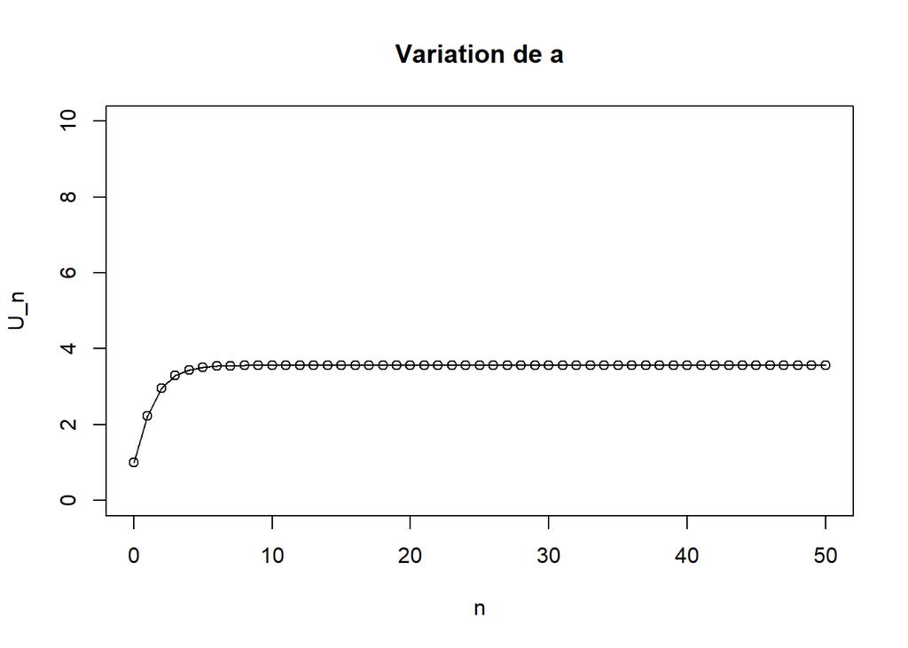

```r
plot(0:N, derivatives$dU_da,
     type = "o", col = 1, ylim = c(0, 10),
     xlab = "n", ylab = "U_n",
     main = "Variation de a")
```

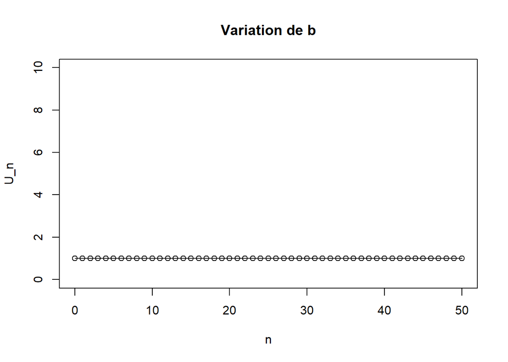

```r
plot(0:N, derivatives$dU_db,
     type = "o", col = 1, ylim = c(0, 10),
     xlab = "n", ylab = "U_n",
     main = "Variation de b")
```

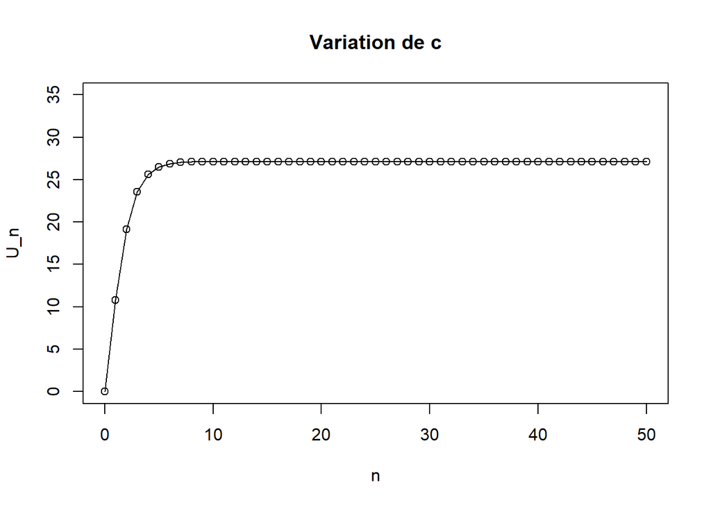

```r
plot(0:N, derivatives$dU_dc,
     type = "o", col = 1, ylim = c(0, 35),
     xlab = "n", ylab = "U_n",
     main = "Variation de c")
```

```r
# Fonction pour calculer l'indicateur de sensibilité à partir des dérivées partielles
sensitivity_indicator_from_derivatives <- function(N, a, b, c, U, dU_da, dU_db, dU_dc) {
  # Calcul de l'indicateur de sensibilité pour chaque paramètre
  S_a <- mean(abs(dU_da[2:(N+1)] * (a / U[2:(N+1)])))  # On évite U0, donc on prend U[2:N+1]
  S_b <- mean(abs(dU_db[2:(N+1)] * (b / U[2:(N+1)])))
  S_c <- mean(abs(dU_dc[2:(N+1)] * (c / U[2:(N+1)])))

  # Retourne les sensibilités
  return(list(S_a = S_a, S_b = S_b, S_c = S_c))
}
```

```r
# Calcul des indicateurs de sensibilité
sensitivities <- sensitivity_indicator_from_derivatives(N, a, b, c, derivatives$U, derivatives$dU_da, derivatives$dU_db, derivatives$dU_dc)

# Affichage des résultats
print(paste("Indicateur de sensibilité par rapport à a: ", sensitivities$S_a))
```

```
## [1] "Indicateur de sensibilité par rapport à a:  0.858127094467141"
```

```r
print(paste("Indicateur de sensibilité par rapport à b: ", sensitivities$S_b))
```

```
## [1] "Indicateur de sensibilité par rapport à b:  0.164853007066989"
```

```r
print(paste("Indicateur de sensibilité par rapport à c: ", sensitivities$S_c))
```

```
## [1] "Indicateur de sensibilité par rapport à c:  1.0712853138923"
```

**Sensibilité élevée par rapport à aux paramètres a et c** . Une sensibilité élevée pour a et c signifie que de petites variations de ces paramètres peuvent entraîner des changements significatifs dans l’évolution de la suite Un. Cela pose un risque de comportement instable du modèle. Par exemple, si ces paramètres sont légèrement mal calibrés, cela pourrait conduire à des résultats imprévisibles ou des valeurs extrêmes pour Un.

**Sensibilité relativement faible par rapport à b :**

La sensibilité faible de b (0.165) indique que ce paramètre a un impact moins significatif sur la dynamique du modèle. Cela signifie que des variations de b n’entraîneront pas de changements majeurs dans la suite Un. Ce paramètre est donc plus robuste et pose moins de risques en termes d’erreurs de calibration.

**Exercise 2.3 Distribution of the parameters**

Les paramètres d’entrée du modèle sont :

*U0* : La condition initiale, qui définit la valeur de départ de la suite U. C’est la première valeur qui déclenche l’évolution de la suite selon les paramètresa,b et c

*N* : Le nombre d’itérations ou d’étapes, représentant la durée sur laquelle la suite est calculée.

*Sorties* : Les sorties du modèle sont : *Un*: La suite de valeurs obtenue après N itérations, où chaque valeur Un dépend des paramètres a,b et c ainsi que de la valeur précédente Un−1. C’est la sortie principale du modèle qui décrit l’évolution de la suite en fonction des entrées.